# Project Two: Logistic Regression and Random Forests

For Project Two, you have been asked to create different models analyzing a Heart Disease data set. Before beginning work on the project, be sure to read through the Project Two Guidelines and Rubric to understand what you need to do and how you will be graded on this assignment. Be sure to carefully review the Project Two Summary Report template, which contains all of the questions that you will need to answer about the regression analyses you are performing.

For this project, you will be writing all the scripts yourself. You may reference the textbook and your previous work on the problem sets to help you write the scripts.

### Scenario

You are a data analyst researching risk factors for heart disease at a university hospital. You have access to a large set of historical data that you can use to analyze patterns between different health indicators (e.g. fasting blood sugar, maximum heart rate, etc.) and the presence of heart disease. You have been asked to create different logistic regression models that predict whether or not a person is at risk for heart disease. A model like this could eventually be used to evaluate medical records and look for risks that might not be obvious to human doctors. You have also been asked to create a classification random forest model to predict the risk of heart disease and a regression random forest model to predict the maximum heart rate achieved.

There are several variables in this data set, but you will be working with the following important variables:

[output not shown]

## Install Libraries

In the following code block, you will install appropriate libraries to use in this project.

```r
print("This step will first install three R packages. Please wait until the packages are fully installed.")
print("Once the installation is complete, this step will print 'Installation complete!'")

install.packages("ResourceSelection")
install.packages("pROC")
install.packages("rpart.plot")

print("Installation complete!")
```

```
[1] "This step will first install three R packages. Please wait until the packages are fully installed."
[1] "Once the installation is complete, this step will print 'Installation complete!'"
```

```
[1] "Installation complete!"
```

## Prepare Your Data Set

In the following code block, you have been given the R code to prepare your data set.

Click the **Run** button on the toolbar to run this code.

```r
heart_data <- read.csv(file="heart_disease.csv", header=TRUE, sep=",")

# Converting appropriate variables to factors
heart_data <- within(heart_data, {
   target <- factor(target)
   sex <- factor(sex)
   cp <- factor(cp)
   fbs <- factor(fbs)
   restecg <- factor(restecg)
   exang <- factor(exang)
   slope <- factor(slope)
   ca <- factor(ca)
   thal <- factor(thal)
})

head(heart_data, 10)

print("Number of variables")
ncol(heart_data)

print("Number of rows")
nrow(heart_data)
```

A data.frame: 10 × 14

| age <int> | sex <fct> | cp <fct> | trestbps <int> | chol <int> | fbs <fct> | restecg <fct> | thalach <int> | exang <fct> | oldpeak <dbl> | slope <fct> | ca <fct> | thal <fct> | target <fct> |
| --- | --- | --- | --- | --- | --- | --- | --- | --- | --- | --- | --- | --- | --- |
| 62 | 1 | 2 | 130 | 231 | 0 | 1 | 146 | 0 | 1.8 | 1 | 3 | 3 | 1 |
| 58 | 0 | 0 | 130 | 197 | 0 | 1 | 131 | 0 | 0.6 | 1 | 0 | 2 | 1 |
| 60 | 0 | 3 | 150 | 240 | 0 | 1 | 171 | 0 | 0.9 | 2 | 0 | 2 | 1 |
| 63 | 1 | 0 | 140 | 187 | 0 | 0 | 144 | 1 | 4.0 | 2 | 2 | 3 | 0 |
| 62 | 1 | 0 | 120 | 267 | 0 | 1 | 99 | 1 | 1.8 | 1 | 2 | 3 | 0 |
| 63 | 0 | 2 | 135 | 252 | 0 | 0 | 172 | 0 | 0.0 | 2 | 0 | 2 | 1 |
| 43 | 1 | 0 | 150 | 247 | 0 | 1 | 171 | 0 | 1.5 | 2 | 0 | 2 | 1 |
| 42 | 1 | 2 | 120 | 240 | 1 | 1 | 194 | 0 | 0.8 | 0 | 0 | 3 | 1 |
| 59 | 1 | 2 | 126 | 218 | 1 | 1 | 134 | 0 | 2.2 | 1 | 1 | 1 | 0 |
| 48 | 1 | 0 | 124 | 274 | 0 | 0 | 166 | 0 | 0.5 | 1 | 0 | 3 | 0 |

```
[1] "Number of variables"
```

14

```
[1] "Number of rows"
```

303

## Model #1 - First Logistic Regression Model

You have been asked to create a logistic regression model for heart disease *(target)* using the variables age *(age)*, resting blood pressure *(trestbps)*, exercised induced angina (exang) and maximum heart rate achieved *(thalach)*. Before writing any code, review Section 3 of the Summary Report template to see the questions you will be answering about your logistic regression model.

Run your scripts to get the outputs of your regression analysis. Then use the outputs to answer the questions in your summary report.

**Note: Use the + (plus) button to add new code blocks, if needed.**

```r
logit1 <- glm(target ~ age + trestbps + exang + thalach, data = heart_data, family = 'binomial')

summary(logit1)
```

```
Call:
glm(formula = target ~ age + trestbps + exang + thalach, family = "binomial",
    data = heart_data)

Deviance Residuals:
    Min       1Q   Median       3Q      Max
-2.0935  -0.7944   0.4954   0.8133   2.2343

Coefficients:
             Estimate Std. Error z value Pr(>|z|)
(Intercept) -1.021121   1.784194  -0.572   0.5671
age         -0.017549   0.017144  -1.024   0.3060
trestbps    -0.014888   0.008337  -1.786   0.0741 .
exang1      -1.624981   0.305774  -5.314 1.07e-07 ***
thalach      0.031095   0.007275   4.274 1.92e-05 ***
---
Signif. codes:  0 '***' 0.001 '**' 0.01 '*' 0.05 '.' 0.1 ' ' 1

(Dispersion parameter for binomial family taken to be 1)

    Null deviance: 417.64  on 302  degrees of freedom
Residual deviance: 323.14  on 298  degrees of freedom
AIC: 333.14

Number of Fisher Scoring iterations: 4
```

```r
library("ResourceSelection")
print("Hosmer-Lemeshow Goodness of Fit Test")
hoslem.test(logit1$y, fitted(logit1), g=50)

print("Wald's Test CI @ 5%")
confint.default(logit1, level=0.95)
```

```
[1] "Hosmer-Lemeshow Goodness of Fit Test"
```

```
	Hosmer and Lemeshow goodness of fit (GOF) test

data:  logit1$y, fitted(logit1)
X-squared = 44.622, df = 48, p-value = 0.612
```

```
[1] "Wald's Test CI @ 5%"
```

A matrix: 5 × 2 of type dbl

|  | 2.5 % | 97.5 % |
| --- | --- | --- |
| (Intercept) | -4.51807763 | 2.475836126 |
| age | -0.05115052 | 0.016052472 |
| trestbps | -0.03122942 | 0.001452574 |
| exang1 | -2.22428805 | -1.025674485 |
| thalach | 0.01683588 | 0.045354951 |

```r
# Model Predictions (Fitted Values)
default_model_data1 <- heart_data[c('age', 'trestbps', 'exang', 'thalach')]
pred1 <- predict(logit1, newdata=default_model_data1, type='response')

# predicted probability of target is >=0.50 then target='1', otherwise target='0'
depvar_pred1 = as.factor(ifelse(pred1 >= 0.5, '1', '0'))

# confusion matrix
conf.matrix1 <- table(heart_data$target, depvar_pred1)[c('0','1'),c('0','1')]
rownames(conf.matrix1) <- paste("Actual", rownames(conf.matrix1), sep = ": disease=")
colnames(conf.matrix1) <- paste("Prediction", colnames(conf.matrix1), sep = ": disease=")

# Print nicely formatted confusion matrix
print("Confusion Matrix")
format(conf.matrix1,justify="centre",digit=2)
```

```
[1] "Confusion Matrix"
```

A matrix: 2 × 2 of type chr

|  | Prediction: disease=0 | Prediction: disease=1 |
| --- | --- | --- |
| Actual: disease=0 | 89 | 49 |
| Actual: disease=1 | 31 | 134 |

```r
# Call for roc function
library(pROC)

# ROC Setup
hd_labels <- heart_data$target
predictions1 <- logit1$fitted.values

# ROC Excute w/ AUC
roc1 <- roc(hd_labels ~ predictions1)
print("Area Under the Curve (AUC)")
round(auc(roc1),4)
```

```
[1] "Area Under the Curve (AUC)"
```

0.8007

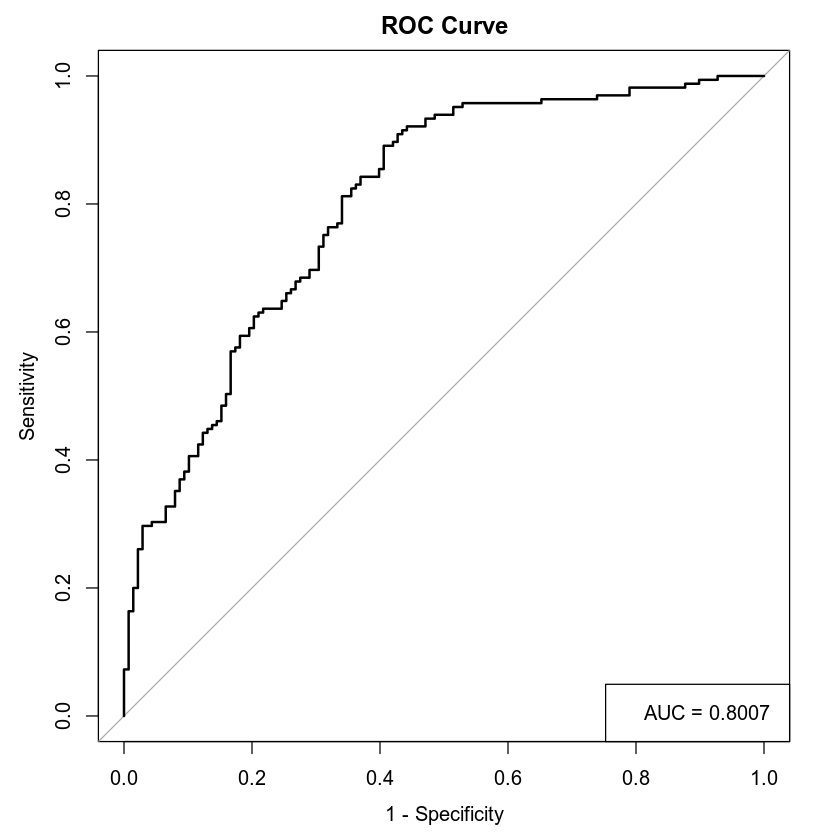

```r
# Plot ROC Curve w/ AUC
plot(roc1, main = "ROC Curve", legacy.axes = TRUE)
legend("bottomright", legend = "AUC = 0.8007")
```

```r
# Model Predictions

# Prediction 1: age=50, trestbps=122, exang=1, thalach=140
print("Prediction 1: age=50, trestbps=122, exang=1, thalach=140")
hd_data1 <- data.frame(age=50, trestbps=122, exang="1", thalach=140)
predict(logit1, hd_data1, type="response")

# Prediction 2: age=50, trestbps=130, exang=0, thalach=165
print("Prediction 2: age=50, trestbps=130, exang=0, thalach=165")
hd_data2 <- data.frame(age=50, trestbps=130, exang="0", thalach=165)
predict(logit1, hd_data2, type="response")
```

```
[1] "Prediction 1: age=50, trestbps=122, exang=1, thalach=140"
```

**1:** 0.271587649511907

```
[1] "Prediction 2: age=50, trestbps=130, exang=0, thalach=165"
```

**1:** 0.78527518060083

## Model #2 - Second Logistic Regression Model

You have been asked to create a logistic regression model for heart disease *(target)* using the variables age of the individual *(age)*, resting blood pressure (trestbps), type of chest pain *(cp)* and maximum heart rate achieved *(thalach)*. You also have to include the quadratic term for age and the interaction term between age and maximum heart rate achieved. Before writing any code, review Section 4 of the Summary Report template to see the questions you will be answering about your model.

Run your scripts to get the outputs of your analysis. Then use the outputs to answer the questions in your summary report.

**Note: Use the + (plus) button to add new code blocks, if needed.**

```r
logit2 <- glm(target ~ age + trestbps + cp + thalach + age:thalach + I(age^2), data = heart_data, family = 'binomial')

summary(logit2)
```

```
Call:
glm(formula = target ~ age + trestbps + cp + thalach + age:thalach +
    I(age^2), family = "binomial", data = heart_data)

Deviance Residuals:
    Min       1Q   Median       3Q      Max
-2.6961  -0.7537   0.2925   0.7123   2.3058

Coefficients:
              Estimate Std. Error z value Pr(>|z|)
(Intercept) -1.556e+01  1.054e+01  -1.476  0.13988
age          1.744e-01  2.669e-01   0.653  0.51357
trestbps    -1.958e-02  8.978e-03  -2.181  0.02916 *
cp1          1.913e+00  4.437e-01   4.313 1.61e-05 ***
cp2          2.037e+00  3.473e-01   5.867 4.45e-09 ***
cp3          1.777e+00  5.477e-01   3.245  0.00117 **
thalach      1.363e-01  5.119e-02   2.663  0.00775 **
I(age^2)     8.424e-04  1.750e-03   0.481  0.63025
age:thalach -1.867e-03  8.909e-04  -2.095  0.03616 *
---
Signif. codes:  0 '***' 0.001 '**' 0.01 '*' 0.05 '.' 0.1 ' ' 1

(Dispersion parameter for binomial family taken to be 1)

    Null deviance: 417.64  on 302  degrees of freedom
Residual deviance: 293.67  on 294  degrees of freedom
AIC: 311.67

Number of Fisher Scoring iterations: 5
```

```r
library("ResourceSelection")
print("Hosmer-Lemeshow Goodness of Fit Test")
hoslem.test(logit2$y, fitted(logit2), g=50)

print("Wald's Test CI @ 5%")
confint.default(logit2, level=0.95)
```

```
[1] "Hosmer-Lemeshow Goodness of Fit Test"
```

```
	Hosmer and Lemeshow goodness of fit (GOF) test

data:  logit2$y, fitted(logit2)
X-squared = 52, df = 48, p-value = 0.3209
```

```
[1] "Wald's Test CI @ 5%"
```

A matrix: 9 × 2 of type dbl

|  | 2.5 % | 97.5 % |
| --- | --- | --- |
| (Intercept) | -36.227237492 | 5.0998909094 |
| age | -0.348759037 | 0.6974956169 |
| trestbps | -0.037180982 | -0.0019868968 |
| cp1 | 1.043897317 | 2.7830255186 |
| cp2 | 1.356582965 | 2.7178036894 |
| cp3 | 0.703904238 | 2.8506982033 |
| thalach | 0.035985074 | 0.2366580519 |
| I(age^2) | -0.002587547 | 0.0042723904 |
| age:thalach | -0.003612572 | -0.0001204385 |

```r
# Model Predictions (Fitted Values)
default_model_data2 <- heart_data[c('age', 'trestbps', 'cp', 'thalach')]
pred2 <- predict(logit2, newdata=default_model_data2, type='response')

# predicted probability of target is >=0.50 then target='1', otherwise target='0'
depvar_pred2 = as.factor(ifelse(pred2 >= 0.5, '1', '0'))

# confusion matrix
conf.matrix2 <- table(heart_data$target, depvar_pred2)[c('0','1'),c('0','1')]
rownames(conf.matrix2) <- paste("Actual", rownames(conf.matrix2), sep = ": disease=")
colnames(conf.matrix2) <- paste("Prediction", colnames(conf.matrix2), sep = ": disease=")

# Print nicely formatted confusion matrix
print("Confusion Matrix")
format(conf.matrix2,justify="centre",digit=2)
```

```
[1] "Confusion Matrix"
```

A matrix: 2 × 2 of type chr

|  | Prediction: disease=0 | Prediction: disease=1 |
| --- | --- | --- |
| Actual: disease=0 | 102 | 36 |
| Actual: disease=1 | 36 | 129 |

```r
# Call for roc function
library(pROC)

# ROC Setup
predictions2 <- logit2$fitted.values

# ROC Excute w/ AUC
roc2 <- roc(hd_labels ~ predictions2)
print("Area Under the Curve (AUC)")
round(auc(roc2),4)
```

```
[1] "Area Under the Curve (AUC)"
```

0.8478

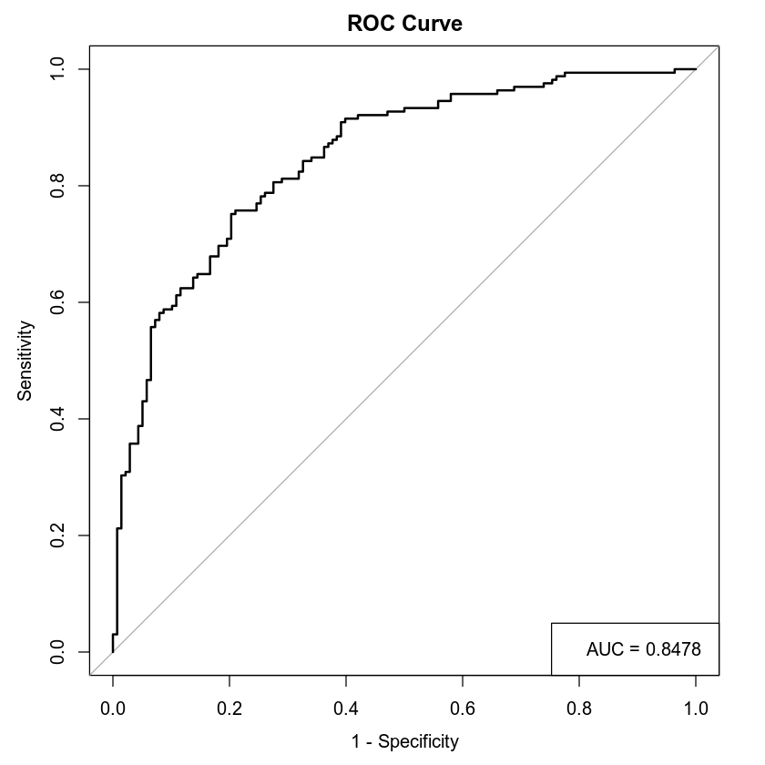

```r
# Plot ROC Curve w/ AUC
plot(roc2, main = "ROC Curve", legacy.axes = TRUE)
legend("bottomright", legend = "AUC = 0.8478")
```

```r
# Model Predictions

# Prediction 1: age=50, trestbps=115, cp=0, thalach=133
print("Prediction 1: age=50, trestbps=115, cp=0, thalach=133")
hd_data3 <- data.frame(age=50, trestbps=115, cp="0", thalach=133)
predict(logit2, hd_data3, type="response")

# Prediction 2: age=50, trestbps=125, cp=1, thalach=155
print("Prediction 2: age=50, trestbps=125, cp=1, thalach=155")
hd_data4 <- data.frame(age=50, trestbps=125, cp="1", thalach=155)
predict(logit2, hd_data4, type="response")
```

```
[1] "Prediction 1: age=50, trestbps=115, cp=0, thalach=133"
```

**1:** 0.218769936989864

```
[1] "Prediction 2: age=50, trestbps=125, cp=1, thalach=155"
```

**1:** 0.800702646393384

## Random Forest Classification Model

You have been asked to create a random forest classification model for the presence of heart disease *(target)* using the variables age *(age)*, sex *(sex)*, chest pain type *(cp)*, resting blood pressure *(trestbps)*, cholesterol measurement *(chol)*, resting electrocardiographic measurement *(restecg)*, exercise-induced angina *(exang)*, and number of major vessels *(ca)*. Before writing any code, review Section 5 of the Summary Report template to see the questions you will be answering about your model.

Run your scripts to get the outputs of your regression analysis. Then use the outputs to answer the questions in your summary report.

**Note: Use the + (plus) button to add new code blocks, if needed.**

```r
set.seed(6522048)
# Partition the data set into training and testing data
samp.size1 = floor(0.85*nrow(heart_data))

# Training set
print("Number of rows for the training set")
train1 = sample(seq_len(nrow(heart_data)), size = samp.size1)
train.data1 = heart_data[train1,]
nrow(train.data1)

# Testing set
print("Number of rows for the validation set")
test.data1 = heart_data[-train1,]
nrow(test.data1)
```

```
[1] "Number of rows for the training set"
```

257

```
[1] "Number of rows for the validation set"
```

46

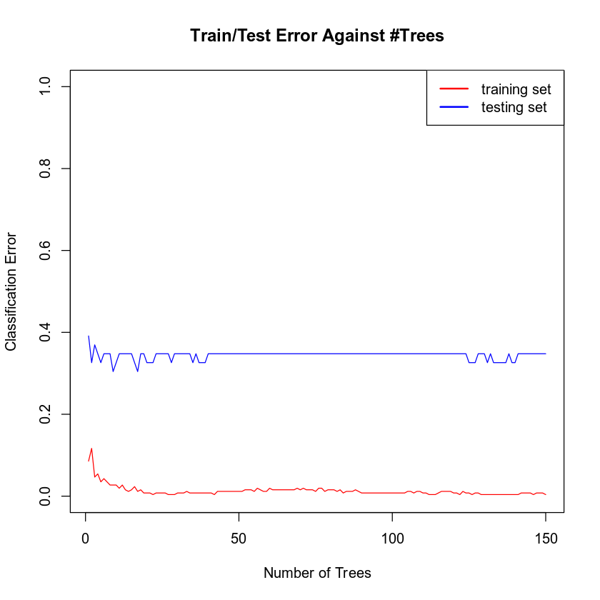

```r
set.seed(6522048)

library(randomForest)

# Checking
#=====================================================================
train = c()
test = c()
trees = c()

for(i in seq(from=1, to=150, by=1)) {
    #print(i)

    trees <- c(trees, i)
    set.seed(6522048)
    rf_clsmodel <- randomForest(target ~ age + sex + cp + trestbps + chol + restecg + exang + ca, data=train.data1, ntree = i)

    train.data.predict <- predict(rf_clsmodel, train.data1, type = "class")
    conf.matrix1 <- table(train.data1$target, train.data.predict)
    train_error = 1-(sum(diag(conf.matrix1)))/sum(conf.matrix1)
    train <- c(train, train_error)

    test.data.predict <- predict(rf_clsmodel, test.data1, type = "class")
    conf.matrix2 <- table(test.data1$target, test.data.predict)
    test_error = 1-(sum(diag(conf.matrix2)))/sum(conf.matrix2)
    test <- c(test, test_error)
}

plot(trees, train,type = "l",ylim=c(0,1),col = "red", main = "Train/Test Error Against #Trees", xlab = "Number of Trees", ylab = "Classification Error")
lines(test, type = "l", col = "blue")
legend('topright',legend = c('training set','testing set'), col = c("red","blue"), lwd = 2 )
```

```r
set.seed(6522048)

# Optimal number of trees appears to be ~20 trees
library(randomForest)
rf_clsmodel <- randomForest(target ~ age + sex + cp + trestbps + chol + restecg + exang + ca, data=train.data1, ntree = 20)

# Confusion matrix
print("======================================================================================================================")
print('Confusion Matrix: TRAINING set based on random forest model built using 20 trees')
train.data.predict <- predict(rf_clsmodel, train.data1, type = "class")

# Construct the confusion matrix
conf.matrix3 <- table(train.data1$target, train.data.predict)[,c('0','1')]
rownames(conf.matrix3) <- paste("Actual", rownames(conf.matrix3), sep = ": disease=")
colnames(conf.matrix3) <- paste("Prediction", colnames(conf.matrix3), sep = ": disease=")

# Print nicely formatted confusion matrix
format(conf.matrix3,justify="centre", digit=2)


print("======================================================================================================================")
print('Confusion Matrix: TESTING set based on random forest model built using 20 trees')
test.data.predict <- predict(rf_clsmodel, test.data1, type = "class")

# Construct the confusion matrix
conf.matrix4 <- table(test.data1$target, test.data.predict)[,c('0','1')]
rownames(conf.matrix4) <- paste("Actual", rownames(conf.matrix4), sep = ": disease=")
colnames(conf.matrix4) <- paste("Prediction", colnames(conf.matrix4), sep = ": disease=")

# Print nicely formatted confusion matrix
format(conf.matrix4,justify="centre",digit=2)
```

```
[1] "======================================================================================================================"
[1] "Confusion Matrix: TRAINING set based on random forest model built using 20 trees"
```

A matrix: 2 × 2 of type chr

|  | Prediction: disease=0 | Prediction: disease=1 |
| --- | --- | --- |
| Actual: disease=0 | 118 | 2 |
| Actual: disease=1 | 0 | 137 |

```
[1] "======================================================================================================================"
[1] "Confusion Matrix: TESTING set based on random forest model built using 20 trees"
```

A matrix: 2 × 2 of type chr

|  | Prediction: disease=0 | Prediction: disease=1 |
| --- | --- | --- |
| Actual: disease=0 | 11 | 7 |
| Actual: disease=1 | 8 | 20 |

## Random Forest Regression Model

You have been asked to create a random forest regression model for maximum heart rate achieved using the variables age *(age)*, sex *(sex)*, chest pain type *(cp)*, resting blood pressure *(trestbps)*, cholesterol measurement *(chol)*, resting electrocardiographic measurement *(restecg)*, exercise-induced angina *(exang)*, and number of major vessels *(ca)*. Before writing any code, review Section 6 of the Summary Report template to see the questions you will be answering about your model.

Run your scripts to get the outputs of your analysis. Then use the outputs to answer the questions in your summary report.

**Note: Use the + (plus) button to add new code blocks, if needed.**

```r
set.seed(6522048)
# Partition the data set into training and testing data
samp.size2 = floor(0.80*nrow(heart_data))

# Training set
print("Number of rows for the training set")
train2 = sample(seq_len(nrow(heart_data)), size = samp.size2)
train.data2 = heart_data[train2,]
nrow(train.data2)

# Testing set
print("Number of rows for the validation set")
test.data2 = heart_data[-train2,]
nrow(test.data2)
```

```
[1] "Number of rows for the training set"
```

242

```
[1] "Number of rows for the validation set"
```

61

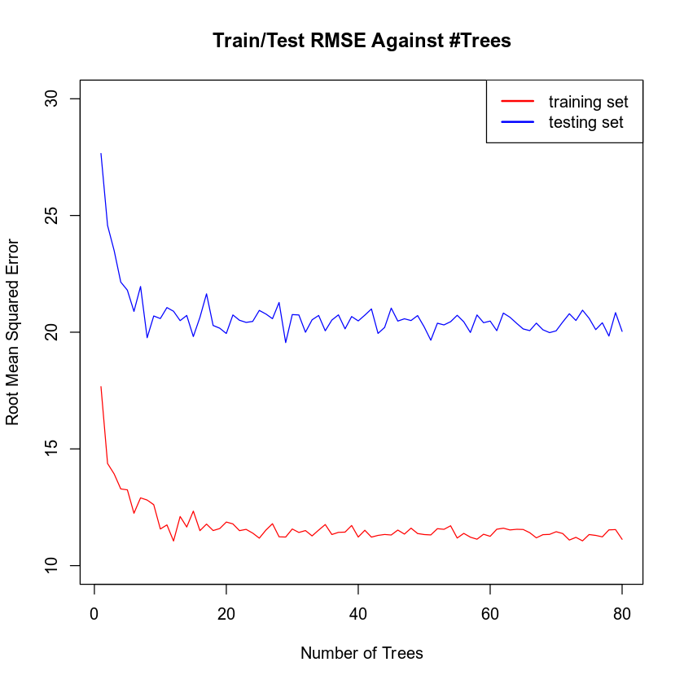

```r
set.seed(6522048)

library(randomForest)

# Root mean squared error
RMSE = function(pred, obs) {
    return(sqrt( sum( (pred - obs)^2 )/length(pred) ) )
}
#=====================================================================
train = c()
test = c()
trees = c()

for(i in seq(from=1, to=80, by=1)) {
    trees <- c(trees, i)
    rf_regmodel <- randomForest(thalach ~ age + sex + cp + trestbps + chol + restecg + exang + ca, data=train.data2, ntree = i)

    pred <- predict(rf_regmodel, newdata=train.data2, type='response')
    rmse_train <-  RMSE(pred, train.data2$thalach)
    train <- c(train, rmse_train)

    pred <- predict(rf_regmodel, newdata=test.data2, type='response')
     rmse_test <-  RMSE(pred, test.data2$thalach)
    test <- c(test, rmse_test)
}

plot(trees, train, type = "l", ylim=c(10,30), col = "red", xlab = "Number of Trees", ylab = "Root Mean Squared Error", main="Train/Test RMSE Against #Trees")
lines(test, type = "l", col = "blue")
legend('topright',legend = c('training set','testing set'), col = c("red","blue"), lwd = 2 )
```

```r
set.seed(6522048)

library(randomForest)

rf_regmodel <- randomForest(thalach ~ age + sex + cp + trestbps + chol + restecg + exang + ca, data=train.data2, ntree = 20)

print("======================================================================================================================")
print('Root Mean Squared Error: TRAINING set based on random forest model built using 20 trees')
pred1 <- predict(rf_regmodel, newdata=train.data2, type='response')
RMSE(pred1, train.data2$thalach)

print("======================================================================================================================")
print('Root Mean Squared Error: TESTING set based on random forest model built using 20 trees')
pred2 <- predict(rf_regmodel, newdata=test.data2, type='response')
RMSE(pred2, test.data2$thalach)
```

```
[1] "======================================================================================================================"
[1] "Root Mean Squared Error: TRAINING set based on random forest model built using 20 trees"
```

11.6281588266415

```
[1] "======================================================================================================================"
[1] "Root Mean Squared Error: TESTING set based on random forest model built using 20 trees"
```

21.1139392413712

## End of Project Two Jupyter Notebook

The HTML output can be downloaded by clicking **File**, then **Download as**, then **HTML**. Be sure to answer all of the questions in the Summary Report template for Project Two, and to include your completed Jupyter Notebook scripts as part of your submission.